# Project - Data Mining

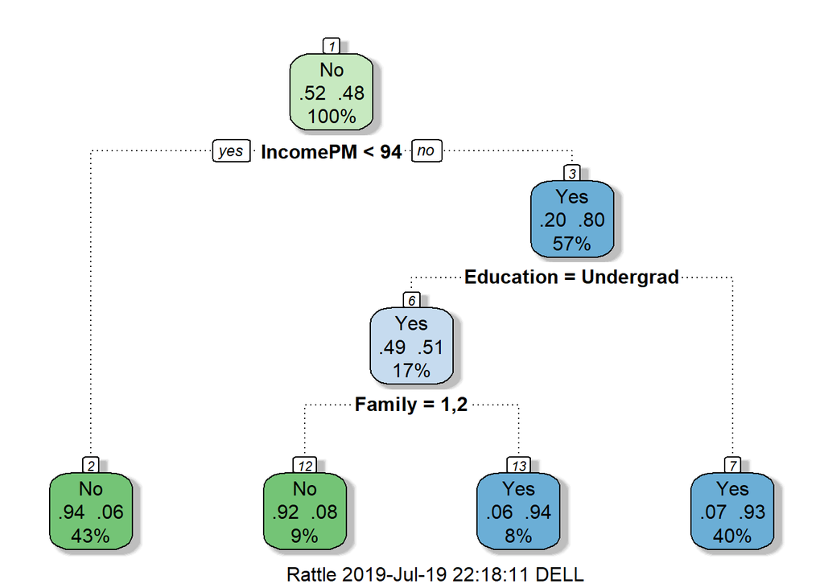

```r
fancyRpartPlot(b_ptree)
```

```r
summary(b_ptree)
```

```
## Call:
## rpart(formula = PersonalLoan ~ Age + Experience + IncomePM +
##     Family + CCAvg + Education + Mortgage + SecuritiesAcct +
##     CDAcct + Online + CreditCard, data = b_train, method = "class",
##     control = b.ctrl)
##   n= 2214
##
##            CP nsplit rel error    xerror       xstd
## 1 0.712022367      0 1.0000000 1.0000000 0.02191564
## 2 0.073625349      1 0.2879776 0.2879776 0.01519631
## 3 0.004349177      3 0.1407269 0.1407269 0.01105477
##
## Variable importance
##  IncomePM     CCAvg    Family Education    CDAcct  Mortgage       Age
##        54        21        12         8         2         2         1
##
## Node number 1: 2214 observations,    complexity param=0.7120224
##   predicted class=No   expected loss=0.4846432  P(node) =1
##     class counts:  1141  1073
##    probabilities: 0.515 0.485
##   left son=2 (948 obs) right son=3 (1266 obs)
##   Primary splits:
##       IncomePM  < 93.85772  to the left,  improve=594.58040, (0 missing)
##       CCAvg     < 3.303662  to the left,  improve=269.49380, (0 missing)
##       CDAcct    splits as  LR, improve=140.63640, (0 missing)
##       Education splits as  LRR, improve= 75.49065, (0 missing)
##       Mortgage  < 290.9162  to the left,  improve= 52.12698, (0 missing)
##   Surrogate splits:
##       CCAvg < 2.405634  to the left,  agree=0.74, adj=0.393, (0 split)
##
## Node number 2: 948 observations
##   predicted class=No   expected loss=0.06118143  P(node) =0.4281843
##     class counts:   890    58
##    probabilities: 0.939 0.061
##
## Node number 3: 1266 observations,    complexity param=0.07362535
##   predicted class=Yes  expected loss=0.1982622  P(node) =0.5718157
##     class counts:   251  1015
##    probabilities: 0.198 0.802
##   left son=6 (377 obs) right son=7 (889 obs)
```

[output cut: 26 more lines]

```
##
## Node number 7: 889 observations
##   predicted class=Yes  expected loss=0.07311586  P(node) =0.4015357
##     class counts:    65   824
##    probabilities: 0.073 0.927
##
## Node number 12: 190 observations
##   predicted class=No   expected loss=0.08421053  P(node) =0.08581752
##     class counts:   174    16
##    probabilities: 0.916 0.084
##
## Node number 13: 187 observations
##   predicted class=Yes  expected loss=0.06417112  P(node) =0.08446251
##     class counts:    12   175
##    probabilities: 0.064 0.936
```

```r
print(b_ptree$variable.importance)
```

```
##  IncomePM     CCAvg    Family Education    CDAcct  Mortgage       Age
## 624.55246 250.02612 136.70169  93.51057  27.77895  21.94384  12.42743
```

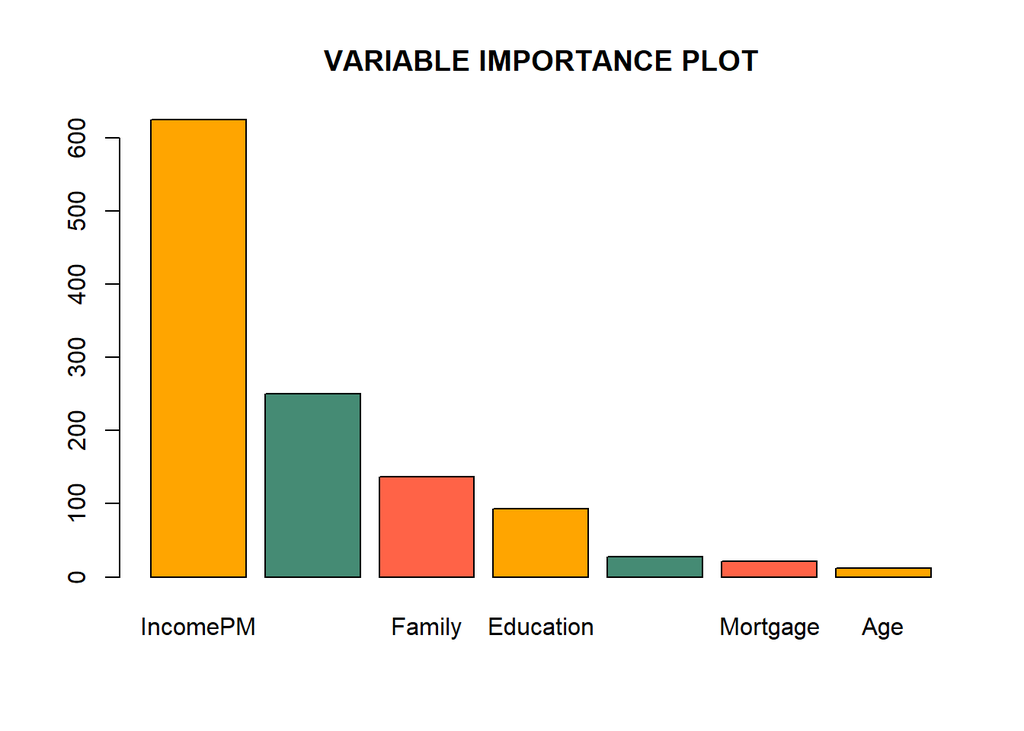

```r
barplot(sort(b_ptree$variable.importance, decreasing = TRUE),main = "VARIABLE IMPORTANCE PLOT", col = c("orange","aquamarine4","tomato"))
```

As we had earlier predicted, income and credit card usage is most important factors for accepting the loan.

```r
#Scoring/Predicting the training and test dataset

b_train$predict.class = predict(b_ptree, data = b_train, type="class")
b_train$predict.score = predict(b_ptree, data = b_train)

head(b_train)
```

|  | Age | Experience | IncomePM | Family | CCAvg | Education | Mortgage | PersonalLoan | SecuritiesAcct | CDAcct | Online | CreditCard | predict.class | predict.score |
| --- | --- | --- | --- | --- | --- | --- | --- | --- | --- | --- | --- | --- | --- | --- |
| 1 | 54.88682 | 26.844330 | 23.33277 | 4 | 0.4697378 | Graduate | 29.39404 | No | No | No | Yes | No | No |  |
| 2 | 31.12344 | 8.642271 | 147.25669 | 2 | 3.1965652 | Undergrad | 154.32811 | No | No | No | No | Yes | No |  |
| 3 | 45.52818 | 26.047742 | 95.99521 | 1 | -0.1750600 | Graduate | -13.33745 | No | No | No | Yes | No | Yes |  |
| 4 | 36.01948 | 10.856346 | 91.94366 | 4 | 2.4876870 | Graduate | 44.17555 | No | No | No | No | No | No |  |
| 6 | 40.61890 | 22.951051 | 95.94778 | 1 | 6.1652139 | Undergrad | 343.96392 | No | No | No | Yes | No | No |  |
| 10 | 47.24579 | 26.838849 | 58.94533 | 1 | 0.9852592 | Graduate | 245.30999 | No | No | No | No | Yes | No |  |

```r
b_test$predict.class = predict(b_ptree, newdata = b_test, type="class")
b_test$predict.score = predict(b_ptree, newdata = b_test)

head(b_test)
```

|  | Age | Experience | IncomePM | Family | CCAvg | Education | Mortgage | PersonalLoan | SecuritiesAcct | CDAcct | Online | CreditCard | predict.class | predict.score |
| --- | --- | --- | --- | --- | --- | --- | --- | --- | --- | --- | --- | --- | --- | --- |
| 5 | 48.81350 | 30.17746 | 27.22331 | 3 | 1.2960432 | Undergrad | 56.050631 | No | No | No | Yes | No | No |  |
| 7 | 51.65222 | 34.24150 | 62.62052 | 1 | 0.9062712 | Advanced/Professional | -29.120350 | No | Yes | No | Yes | No | No |  |
| 8 | 61.54092 | 33.28311 | 44.32142 | 1 | 1.4824460 | Advanced/Professional | 132.918025 | No | Yes | No | Yes | No | No |  |
| 9 | 66.15144 | 37.09678 | 68.58231 | 3 | 1.2489189 | Undergrad | 251.675876 | No | No | No | No | No | No |  |
| 17 | 54.36707 | 38.91015 | 67.87049 | 3 | -0.1810118 | Graduate | -1.185324 | No | No | No | Yes | Yes | No |  |
| 19 | 51.05858 | 23.00508 | 74.71483 | 3 | 1.0128574 | Advanced/Professional | 218.114117 | No | No | No | Yes | Yes | No |  |

## MODEL PERFORMANCE OF CART:

### Confusion matrix:

```r
b.dev = with(b_train,table(PersonalLoan,predict.class))
b.dev
```

```
##             predict.class
## PersonalLoan   No  Yes
##          No  1064   77
##          Yes   74  999
```

```r
b.test = with(b_test,table(PersonalLoan,predict.class))
b.test
```

```
##             predict.class
## PersonalLoan  No Yes
##          No  525  47
##          Yes  46 490
```

### Accuracy:

```r
accu.dev = (b.dev[1,1]+b.dev[2,2])/(b.dev[1,1]+b.dev[1,2]+b.dev[2,1]+b.dev[2,2])

accu.test = (b.test[1,1]+b.test[2,2])/(b.test[1,1]+b.test[1,2]+b.test[2,1]+b.test[2,2])

accu.dev
```

```
## [1] 0.9317977
```

```r
accu.test
```

```
## [1] 0.916065
```

## RANDOM FOREST ON THE DATASET:

```r
setwd("D:/R Progms")
getwd()
```

```
## [1] "D:/R Progms"
```

```r
t.dataRF = readxl::read_xlsx("Thera Bank_Personal_Loan_Modelling-dataset-1 (1).xlsx", sheet = 2)

t.dataRF = na.omit(t.dataRF)

View(t.dataRF)

t.dataRF = t.dataRF[, c(-1,-5)]

t.dataRF$`Family members` = factor(t.dataRF$`Family members`)
t.dataRF$Education = factor(t.dataRF$Education, labels = c("Undergrad", "Graduate", "Advanced/Professional"))
t.dataRF$`Personal Loan` = factor(t.dataRF$`Personal Loan`, labels = c("No", "Yes"))
t.dataRF$`Securities Account` = factor(t.dataRF$`Securities Account`, labels = c("No", "Yes"))
t.dataRF$Online = factor(t.dataRF$Online, labels = c("No", "Yes"))
t.dataRF$CreditCard = factor(t.dataRF$CreditCard, labels = c("No", "Yes"))
t.dataRF$`CD Account` = factor(t.dataRF$`CD Account`,labels = c("No", "Yes")
                            )
library(dplyr)

t.dataRF = t.dataRF %>%
  rename(PersonalLoan = `Personal Loan`,
         Age = `Age (in years)`,
         Experience = `Experience (in years)`,
         IncomePM = `Income (in K/month)`,
         Family = `Family members`,
         SecuritiesAcct = `Securities Account`,
         CDAcct = `CD Account`
         )

View(t.dataRF)
```

```r
library(caTools)
set.seed(2000)
sample = sample.split(t.dataRF,SplitRatio = 0.7)
trainRF = subset(t.dataRF,sample == TRUE)
testRF = subset(t.dataRF, sample == FALSE)
nrow(trainRF)
```

```
## [1] 3322
```

```r
nrow(testRF)
```

```
## [1] 1660
```

```r
prop.table(table(t.dataRF$PersonalLoan))
```

```
##
##        No       Yes
## 0.9040546 0.0959454
```

```r
prop.table(table(trainRF$PersonalLoan))
```

```
##
##         No        Yes
## 0.90457556 0.09542444
```

```r
prop.table(table(testRF$PersonalLoan))
```

```
##
##         No        Yes
## 0.90301205 0.09698795
```

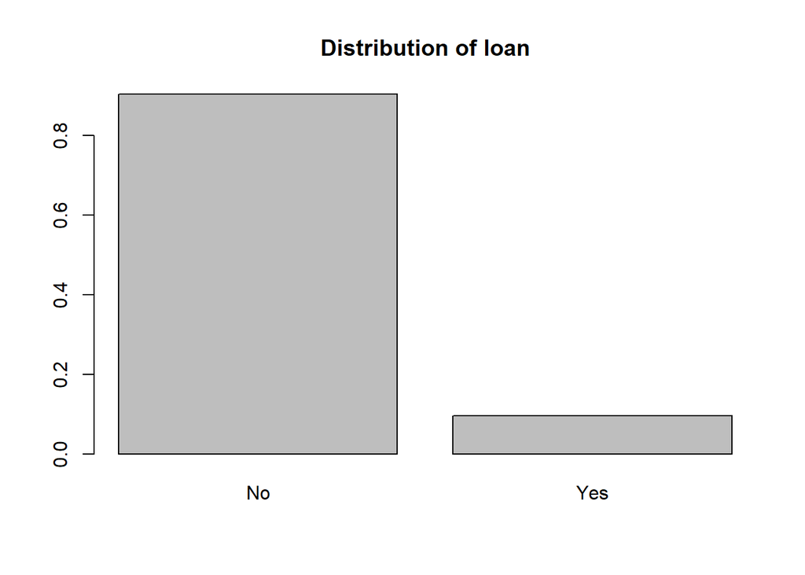

```r
#distribution

barplot(prop.table(table(t.dataRF$PersonalLoan)),
        main = "Distribution of loan")
```

### BALANCING THE IMBALANCED DATA - ROSE

As the data is imbalanced, we are balancing the same with the **ROSE** package as we have done for the CART model.

```r
t.dataRF_balcd = ROSE(formula = PersonalLoan ~. , data = trainRF, p = 0.5, seed = 1)$data

table(t.dataRF_balcd$PersonalLoan)
```

```
##
##   No  Yes
## 1713 1609
```

```r
prop.table(table(t.dataRF_balcd$PersonalLoan))
```

```
##
##        No       Yes
## 0.5156532 0.4843468
```

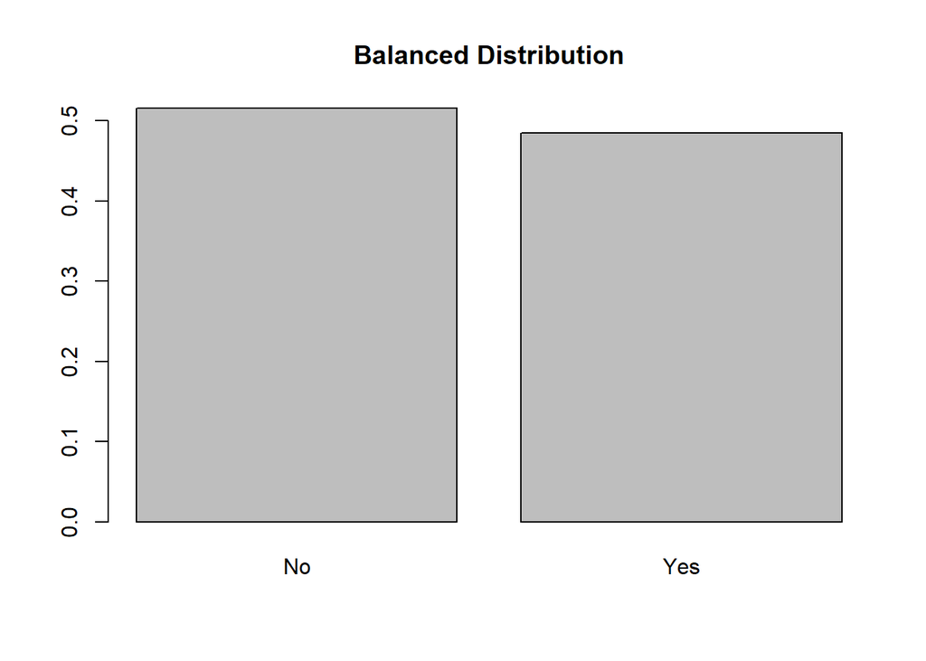

```r
barplot(prop.table(table(t.dataRF_balcd$PersonalLoan)),
        main = "Balanced Distribution")
```

```r
#splitting the balanced data into train and test data

trainRF = subset(t.dataRF_balcd,sample == TRUE)
testRF = subset(t.dataRF_balcd, sample == FALSE)
nrow(trainRF)
```

```
## [1] 2214
```

```r
nrow(testRF)
```

```
## [1] 1108
```

```r
prop.table(table(trainRF$PersonalLoan))
```

```
##
##        No       Yes
## 0.5153568 0.4846432
```

```r
prop.table(table(testRF$PersonalLoan))
```

```
##
##        No       Yes
## 0.5162455 0.4837545
```

## RANDOM FOREST MODEL:

```r
library(randomForest)
set.seed(2500)

#mtry value
RFmtry.val = floor(sqrt(ncol(trainRF)))
RFmtry.val
```

```
## [1] 3
```

```r
#building the first random forest model

RF.m1 = randomForest(PersonalLoan~.,data = trainRF, ntree = 1300, mtry = RFmtry.val ,nodesize = 10, importance = TRUE)

#Print the model to see the OOB and error rate

print(RF.m1)
```

```
##
## Call:
##  randomForest(formula = PersonalLoan ~ ., data = trainRF, ntree = 1300,      mtry = RFmtry.val, nodesize = 10, importance = TRUE)
##                Type of random forest: classification
##                      Number of trees: 1300
## No. of variables tried at each split: 3
##
##         OOB estimate of  error rate: 5.1%
## Confusion matrix:
##       No  Yes class.error
## No  1088   53  0.04645048
## Yes   60 1013  0.05591799
```

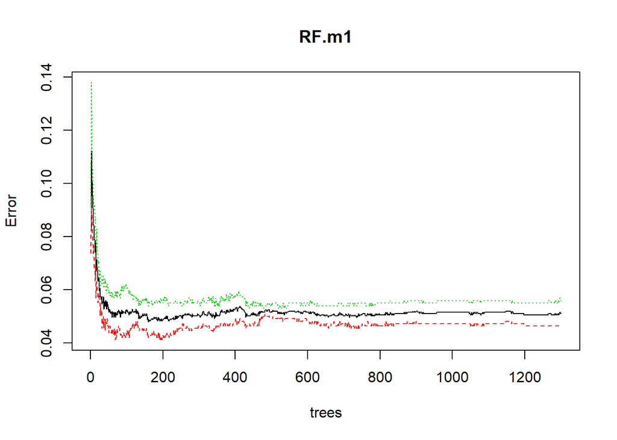

```r
plot(RF.m1)
```

```r
importance(RF.m1)
```

```
##                         No        Yes MeanDecreaseAccuracy
## Age             14.6574944   8.753867             18.03814
## Experience      16.4542173  11.315048             20.77189
## IncomePM       255.7718801 139.778416            230.65140
## Family          99.8996633  87.713395            108.51553
## CCAvg           59.0105776  47.577127             68.48835
## Education      134.1530490 117.567313            146.17257
## Mortgage        48.5302710  25.001407             52.51170
## SecuritiesAcct   1.4015592  14.200681             13.75258
## CDAcct          46.5558644  26.781897             45.83348
## Online          -2.5502308  17.251203             14.66331
## CreditCard       0.4147024  15.804087             15.35575
##                MeanDecreaseGini
## Age                   23.293916
## Experience            23.706609
## IncomePM             498.246341
## Family                69.900950
## CCAvg                161.408918
## Education            101.031794
## Mortgage              54.336424
## SecuritiesAcct         3.209608
## CDAcct                56.663830
## Online                 5.117743
## CreditCard             4.313196
```

### Inference from the above model:

We find that *Income per month* and *Education* are the two most important factors to predict the acceptance of personal loan by the people.

### TUNING THE ALGORITHM:

```
## mtry = 3  OOB error = 5.1%
## Searching left ...
## mtry = 2     OOB error = 5.37%
## -0.05309735 1e-04
## Searching right ...
## mtry = 6     OOB error = 5.33%
## -0.04424779 1e-04
```

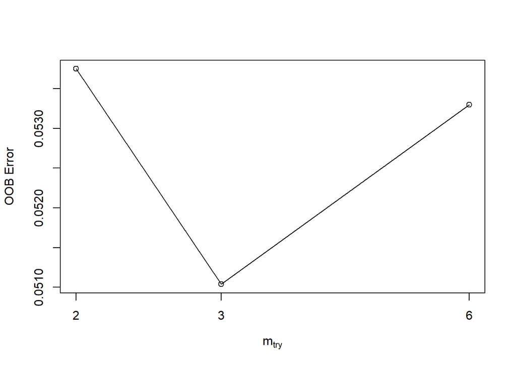

```r
##Tune up the RF model to find out the best mtry

set.seed(2500)

t_RF.m1 = tuneRF(x=trainRF[,-c(8)],y=trainRF$PersonalLoan, mtrystart = 5, stepfactor=1.5, ntree= 830, improve = 0.0001, nodesize=10, trace=TRUE, plot=TRUE, doBest=TRUE, importance=TRUE)
```

# Refined model:

```r
RF.m1 = randomForest(PersonalLoan~.,data = trainRF, ntree = 830, mtry = 3 ,nodesize = 10, importance = TRUE)

##Print the model to see the OOB and error rate
print(RF.m1)
```

```
##
## Call:
##  randomForest(formula = PersonalLoan ~ ., data = trainRF, ntree = 830,      mtry = 3, nodesize = 10, importance = TRUE)
##                Type of random forest: classification
##                      Number of trees: 830
## No. of variables tried at each split: 3
##
##         OOB estimate of  error rate: 5.01%
## Confusion matrix:
##       No  Yes class.error
## No  1089   52  0.04557406
## Yes   59 1014  0.05498602
```

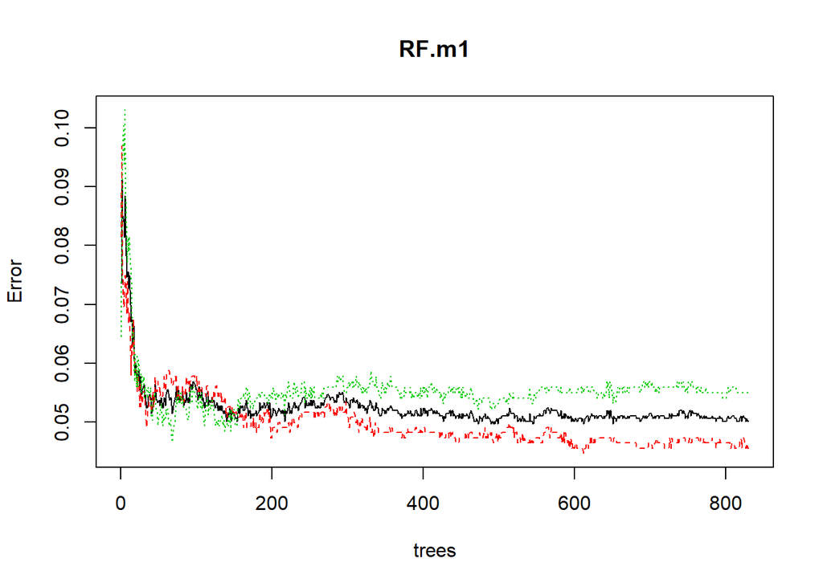

```r
##Plot the RF to know the optimum number of trees
plot(RF.m1)
```

```r
##Identify the importance of the variables
importance(RF.m1)
```

```
##                         No        Yes MeanDecreaseAccuracy
## Age             13.1349278   8.392194             16.40064
## Experience      12.8708271   9.766340             16.53873
## IncomePM       201.3801434 109.203895            183.72089
## Family          76.4215526  67.504390             82.78360
## CCAvg           45.0668774  37.812756             52.82524
## Education      100.9317684  92.724260            112.71712
## Mortgage        37.9101543  19.293230             40.80757
## SecuritiesAcct   0.7658661  11.614846             11.31073
## CDAcct          36.5401806  21.841632             36.71098
## Online          -1.3465299  13.756861             12.19864
## CreditCard       0.3833301  12.445993             12.45379
##                MeanDecreaseGini
## Age                   23.841074
## Experience            24.869533
## IncomePM             493.595553
## Family                66.718504
## CCAvg                160.724285
## Education            100.050675
## Mortgage              58.121720
## SecuritiesAcct         3.359070
## CDAcct                59.404865
## Online                 4.876230
## CreditCard             4.578369
```

**Inference: Our Out Of Bag (OOB) Error rate has reduced slightly from 5.1% to 5.01%**

### Using this tree, prediction is made for the train and the test data:

```r
trainRF$RF.Pred = predict(RF.m1, data = trainRF, type = "class")
trainRF$RF.Score = 1-predict(RF.m1, data = trainRF, type = "prob")[,2]
testRF$RF.Pred = predict(RF.m1, newdata = testRF, type = "class")
testRF$RF.Score = 1-predict(RF.m1, newdata = testRF, type = "prob")[,2]
```

### Confusion matrix:

```r
t_devRF <- with(trainRF,table(PersonalLoan,RF.Pred))
t_devRF
```

```
##             RF.Pred
## PersonalLoan   No  Yes
##          No  1089   52
##          Yes   59 1014
```

```r
t_testRF <- with(testRF,table(PersonalLoan,RF.Pred))
t_testRF
```

```
##             RF.Pred
## PersonalLoan  No Yes
##          No  551  21
##          Yes  35 501
```

### Accuracy measurement:

```r
accu.devRF = (t_devRF[1,1]+t_devRF[2,2])/(t_devRF[1,1]+t_devRF[1,2]+t_devRF[2,1]+t_devRF[2,2])

accu.testRF = (t_testRF[1,1]+t_testRF[2,2])/(t_testRF[1,1]+t_testRF[1,2]+t_testRF[2,1]+t_testRF[2,2])

accu.devRF
```

```
## [1] 0.9498645
```

```r
accu.testRF
```

```
## [1] 0.9494585
```

## MODEL PERFORMANCE MEASURES:

```r
library(ROCR)
library(ineq)
library(InformationValue)
```

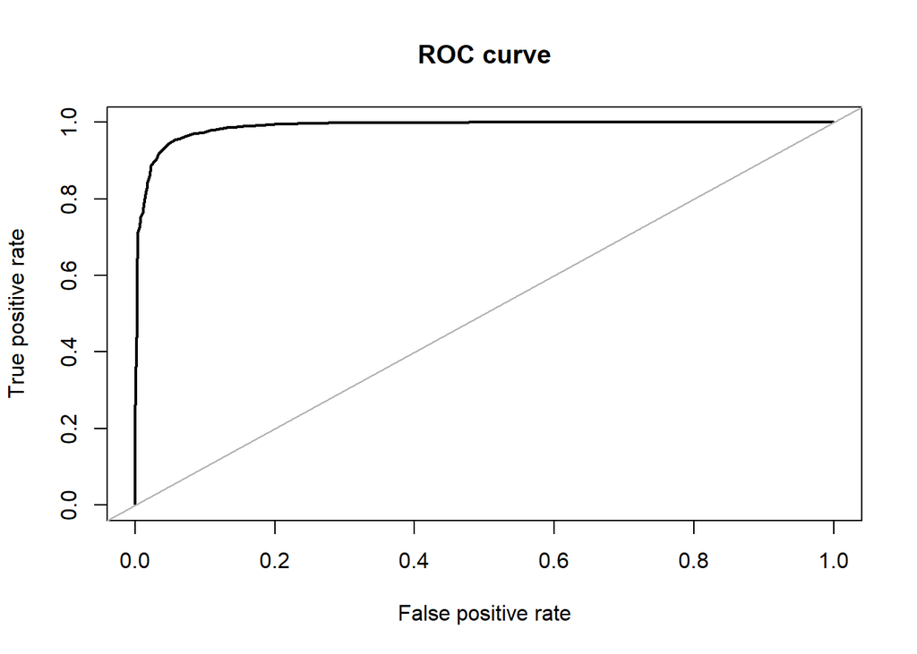

```r
# RANDOM FOREST:

#AUC
auc.train = roc.curve(trainRF$PersonalLoan, trainRF$RF.Score)
```

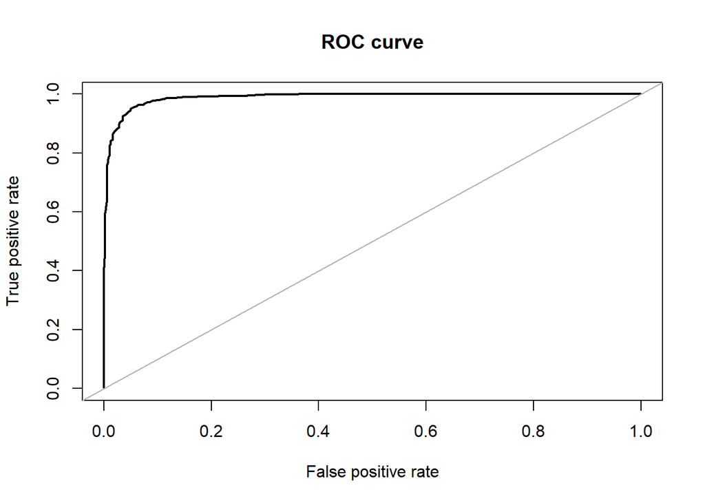

```r
auc.test = roc.curve(testRF$PersonalLoan, testRF$RF.Score)
```

```r
#the model performance is very good as the curve is almost at 1 which relates to high accuracy in both the train as well as in the test models

#gini

ineq(trainRF$RF.Score,"gini")
```

```
## [1] 0.4548052
```

```r
ineq(testRF$RF.Score,"gini")
```

```
## [1] 0.4494381
```